# 82fc3a08-227d-4f5d-97aa-8a0078465ac7

Добрый день.

Итак, мы имеем задачу выявить определяющие успешность игры закономерности для интернет-магазина «Стримчик», который продаёт по всему миру компьютерные игры. Это позволит сделать ставку на потенциально популярный продукт и спланировать рекламные кампании.

В процессе исследования мы выполним 5 шагов:откроем файл с данными и изучим общую информацию, подготовим данные, проведем исследовательский анализ данных, составим портрет пользователя каждого региона, проверим две гипотезы: средние пользовательские рейтинги платформ Xbox One и PC одинаковые и средние пользовательские рейтиги жанров Action и Sports разные.

Целью исследования является закономерности, определяющие успешность игры для дальнейшего планирования кампаний на 2017 год.

Изучим предоставленный нам файл.

```python
import pandas as pd
import numpy as np
import seaborn as sns
import matplotlib.pyplot as plt
data = pd.read_csv('/datasets/games.csv')
```

```python
data.info()
print(data.head(20))
```

```
<class 'pandas.core.frame.DataFrame'>
RangeIndex: 16715 entries, 0 to 16714
Data columns (total 11 columns):
 #   Column           Non-Null Count  Dtype
---  ------           --------------  -----
 0   Name             16713 non-null  object
 1   Platform         16715 non-null  object
 2   Year_of_Release  16446 non-null  float64
 3   Genre            16713 non-null  object
 4   NA_sales         16715 non-null  float64
 5   EU_sales         16715 non-null  float64
 6   JP_sales         16715 non-null  float64
 7   Other_sales      16715 non-null  float64
 8   Critic_Score     8137 non-null   float64
 9   User_Score       10014 non-null  object
```

[output cut: 68 more lines]

Мы получили файл, состоящий из 16715 строк с данными по продажам, рейтингу и годам выпуска 16715 видеоигр, и из 11 столбцов, в которых эти данные и находятся.

Приведем название столбцов к нижнему регистру.

```python
data.columns = data.columns.str.lower()
print(data.columns.unique())
```

```
Index(['name', 'platform', 'year_of_release', 'genre', 'na_sales', 'eu_sales',
       'jp_sales', 'other_sales', 'critic_score', 'user_score', 'rating'],
      dtype='object')
```

В столбце "Name" у двух игр отуствует название. Это может быть обидным пропуском, для создателей игр, но на ход нашего исследования не повлияет.

Типы платформ проставлены все.

```python
data['year_of_release'] = data['year_of_release'].fillna(0)
data['year_of_release'] = data['year_of_release'].astype('int64')
data = data[data['year_of_release'] > 0]
```

```python
columns_to_replace=['name', 'genre', 'rating']

for columns in columns_to_replace:
    data[columns]=data[columns].fillna('unknown')
```

```python
print(data.isna().sum())
```

```
name                  0
platform              0
year_of_release       0
genre                 0
na_sales              0
eu_sales              0
jp_sales              0
other_sales           0
critic_score       8463
user_score         6607
rating                0
dtype: int64
```

В столбце жанров тоже два пропуска, которые мы заменили на unknow.

Столбцы с данными о продажах заполнены полностью.

Данные в столбце с оценками критиков заполнены на 48.68%. Возможно, совсем не поддались критике игры, не оценненые, а, возможно, их забыли проставить, а возможно, их не успели еще оценить. Мы не можем быть уверенны о причинах пропуска данных.

Данные в столбце user_score изучим подробнее:

```python
print(data['user_score'].unique())
```

```
['8' nan '8.3' '8.5' '6.6' '8.4' '8.6' '7.7' '6.3' '7.4' '8.2' '9' '7.9'
 '8.1' '8.7' '7.1' '3.4' '5.3' '4.8' '3.2' '8.9' '6.4' '7.8' '7.5' '2.6'
 '7.2' '9.2' '7' '7.3' '4.3' '7.6' '5.7' '5' '9.1' '6.5' 'tbd' '8.8' '6.9'
 '9.4' '6.8' '6.1' '6.7' '5.4' '4' '4.9' '4.5' '9.3' '6.2' '4.2' '6' '3.7'
 '4.1' '5.8' '5.6' '5.5' '4.4' '4.6' '5.9' '3.9' '3.1' '2.9' '5.2' '3.3'
 '4.7' '5.1' '3.5' '2.5' '1.9' '3' '2.7' '2.2' '2' '9.5' '2.1' '3.6' '2.8'
 '1.8' '3.8' '0' '1.6' '9.6' '2.4' '1.7' '1.1' '0.3' '1.5' '0.7' '1.2'
 '2.3' '0.5' '1.3' '0.2' '0.6' '1.4' '0.9' '1' '9.7']
```

Заменим значения tbd на nan и изменим тип данных, т.к. нам предстоят расчеты и построение диаграмм на основании данных столбца оценок пользователей.

```python
data['user_score'] = data ['user_score'].replace('tbd', np.nan)
print(data['user_score'].unique())
data['user_score'] = data['user_score'].astype('float64')
```

```
['8' nan '8.3' '8.5' '6.6' '8.4' '8.6' '7.7' '6.3' '7.4' '8.2' '9' '7.9'
 '8.1' '8.7' '7.1' '3.4' '5.3' '4.8' '3.2' '8.9' '6.4' '7.8' '7.5' '2.6'
 '7.2' '9.2' '7' '7.3' '4.3' '7.6' '5.7' '5' '9.1' '6.5' '8.8' '6.9' '9.4'
 '6.8' '6.1' '6.7' '5.4' '4' '4.9' '4.5' '9.3' '6.2' '4.2' '6' '3.7' '4.1'
 '5.8' '5.6' '5.5' '4.4' '4.6' '5.9' '3.9' '3.1' '2.9' '5.2' '3.3' '4.7'
 '5.1' '3.5' '2.5' '1.9' '3' '2.7' '2.2' '2' '9.5' '2.1' '3.6' '2.8' '1.8'
 '3.8' '0' '1.6' '9.6' '2.4' '1.7' '1.1' '0.3' '1.5' '0.7' '1.2' '2.3'
 '0.5' '1.3' '0.2' '0.6' '1.4' '0.9' '1' '9.7']
```

Последний столбец содержит данные рейтинга от организации, которая присваивает компьютерным играм подходящую возрастную категорию и определяет рейтинг игры. Данные представлены только на 59.53%. А это уже существенное отсутствие данных. Отбросить данные мы не можем, но и проставить расчетные данные невозможно. Т.к. в задании есть шаг с изучением влияния рейтинга на продажи, то в реальном исследовании таблицу следовало бы вернуть на добработку, как минимум до некритичного 5% - 10% отсутствия данных. В нашем же исследовании мы заменили пропуски на unknow.

```python
data.duplicated().sum()
```

```
0
```

```python
data['sum_sales'] = data['na_sales'] + data['eu_sales'] + data['jp_sales'] + data['other_sales']
```

Вывод по подготовке данных:

мы заменили названия столбцов (привели к нижнему регистру);

преобразовали данные в нужные типы: столбец дат выпуска привели к формату int, а столбец с оценками пользователей к формату float для дальнейшей группировки, расчетов, формирования диаграмм;

обработали пропуски: заменили все пропуски в названиях игр, жанров и рейтинга на unknow, а данные в столбце с оценками критиков были заполнены на 48.68%. Возможно, совсем не поддались критике игры, а, возможно, их забыли проставить, а возможно, их не успели еще оценить. Мы не можем быть уверенны о причинах пропуска данных и не можем их иправить самостоятельно. Заменили значения tbd в столбце user_score на nan и также изменили тип данных в столбце;

посчитали суммарные продажи во всех регионах и записали их в отдельный столбец sum_sales.

Исследовательский анализ данных

```python
#посмотрим, сколько игр выпусклось в разные годы
data['year_of_release'].unique()
```

```
array([2006, 1985, 2008, 2009, 1996, 1989, 1984, 2005, 1999, 2007, 2010,
       2013, 2004, 1990, 1988, 2002, 2001, 2011, 1998, 2015, 2012, 2014,
       1992, 1997, 1993, 1994, 1982, 2016, 2003, 1986, 2000, 1995, 1991,
       1981, 1987, 1980, 1983])
```

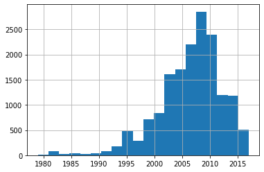

```python
data['year_of_release'].hist(bins = 20, range=(1979, 2017))
```

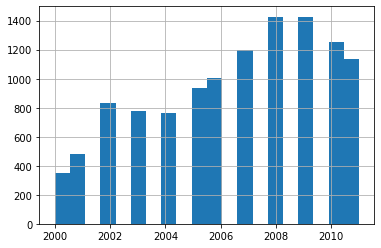

```python
data['year_of_release'].hist(bins = 20, range=(2000, 2011))
```

Вот здесь мы уже точнее видим, что 2008 и 2009 года были самые продуктивные.

```python
#посмотрим, как менялись продажи по платформам, в частности, изучим платформы с наибольшими суммарными продажами (топ-10)
plat_name =data['platform'].unique()
print(plat_name)
```

```
['Wii' 'NES' 'GB' 'DS' 'X360' 'PS3' 'PS2' 'SNES' 'GBA' 'PS4' '3DS' 'N64'
 'PS' 'XB' 'PC' '2600' 'PSP' 'XOne' 'WiiU' 'GC' 'GEN' 'DC' 'PSV' 'SAT'
 'SCD' 'WS' 'NG' 'TG16' '3DO' 'GG' 'PCFX']
```

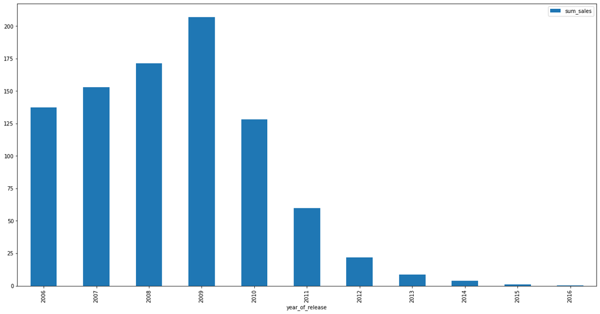

```python
#построим график для платформы Wii, что бы увидеть срок ее действия и как менялись на протяжении всего срока продажи

data[data['platform'] == 'Wii'].pivot_table(index='year_of_release', values='sum_sales', aggfunc='sum').plot(kind='bar', figsize=(20,10))
```

Платформа Wii просуществовала чуть больше 10 лет. Пик продаж пришелся на 2009 год и была достигнута рекордная сумма от продаж.

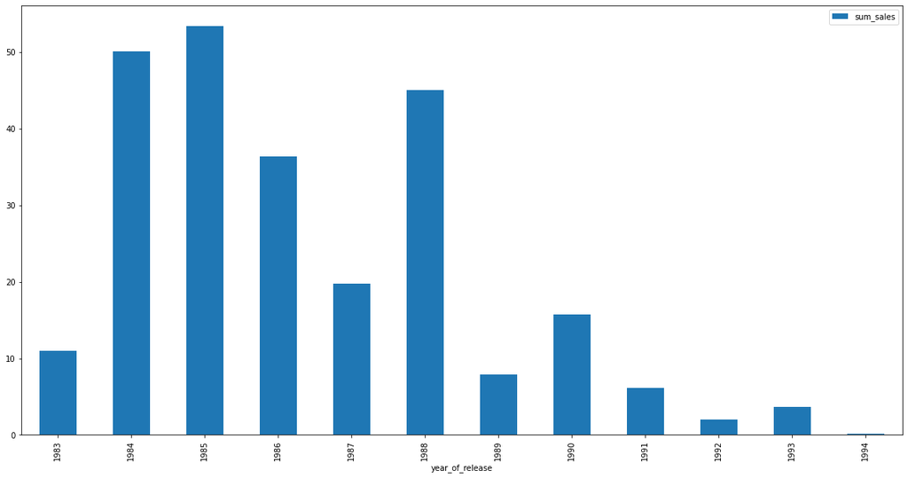

```python
#построим график для платформы NES, что бы увидеть срок ее действия и как менялись на протяжении всего срока продажи
data[data['platform'] == 'NES'].pivot_table(index='year_of_release', values='sum_sales', aggfunc='sum').plot(kind='bar', figsize=(20,10))
```

Платформа NES была одной из первых платформ. Можно также сказать, что просуществовала 10 лет. И пик продаж пришлеся на 1985 год.

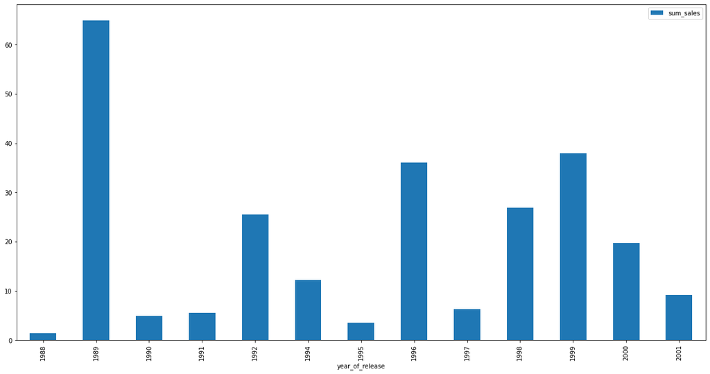

```python
#построим график для платформы GB, что бы увидеть срок ее действия и как менялись на протяжении всего срока продажи
data[data['platform'] == 'GB'].pivot_table(index='year_of_release', values='sum_sales', aggfunc='sum').plot(kind='bar', figsize=(20,10))
```

Платформа GB просуществовала больше, чем предыдущие, более 13 лет. Пик продаж произошел в 1989 году. Можно предположить, что резкий прорыв по продажам произошел из-за обновления игры или отличному рекламному ходу, т.к. программа продавалась и до 1989 года.

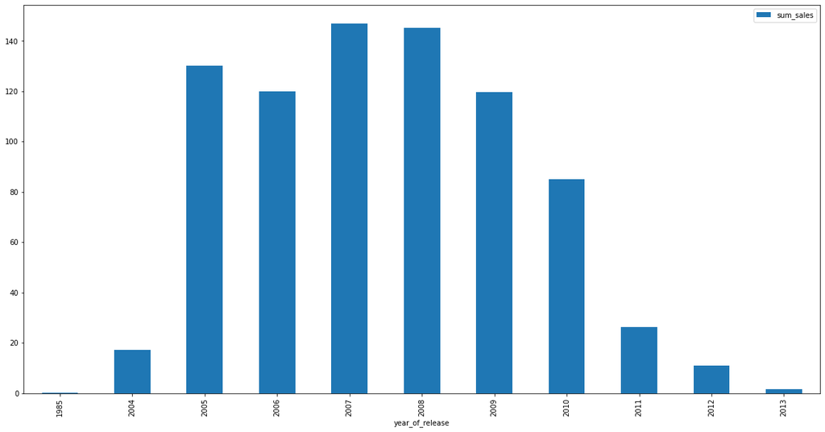

```python
#построим график для платформы DS, что бы увидеть срок ее действия и как менялись на протяжении всего срока продажи
data[data['platform'] == 'DS'].pivot_table(index='year_of_release', values='sum_sales', aggfunc='sum').plot(kind='bar', figsize=(20,10))
```

Платформа DS достигла пика в обьемах продаж произошел после 2004года и просуществовала почти 10 лет.

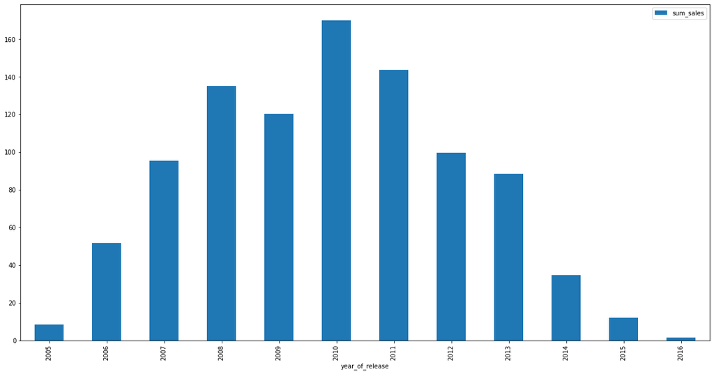

```python
#построим график для платформы X360, что бы увидеть срок ее действия и как менялись на протяжении всего срока продажи
data[data['platform'] == 'X360'].pivot_table(index='year_of_release', values='sum_sales', aggfunc='sum').plot(kind='bar', figsize=(20,10))
```

Платформа Х360 так же сущетсвовала с 2005 года, когда продажи начали расти и достигли пикового значения в 2010 году. Платформа просуществовала более 10 лет и сущетсвует и до сих пор, но уже в минимальных обьемах продаж.

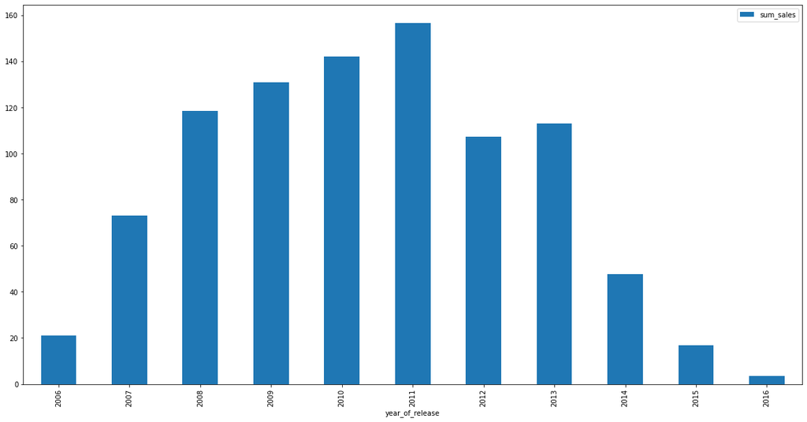

```python
#построим график для платформы PS3, что бы увидеть срок ее действия и как менялись на протяжении всего срока продажи
data[data['platform'] == 'PS3'].pivot_table(index='year_of_release', values='sum_sales', aggfunc='sum').plot(kind='bar', figsize=(20,10))
```

Платформа PS3 так же продается и в 2016 году, просуществовав более 10 лет на рынке. Но свой "звездный час" платформа пережила в конце 2000 - начале 2010 годах. Рекордные суммарные продажи мы видим, но и "закат" очевиден.

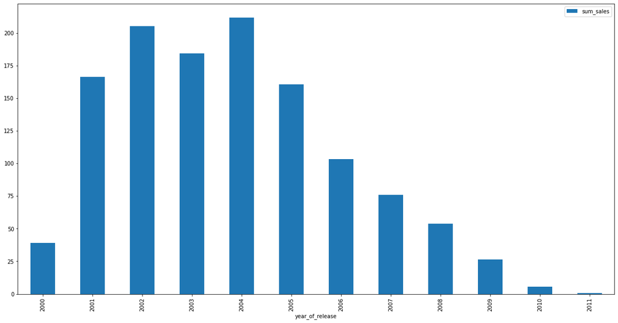

```python
#построим график для платформы PS2, что бы увидеть срок ее действия и как менялись на протяжении всего срока продажи
data[data['platform'] == 'PS2'].pivot_table(index='year_of_release', values='sum_sales', aggfunc='sum').plot(kind='bar', figsize=(20,10))
```

Платформа PS2 просуществовала более 10 лет и была в начале 2000 "царицей платформ". Мы видим рекондные продажи в 2002, 2004 годах. Таких пиковых максимумов нет ни у одной из исследуемых платформ.

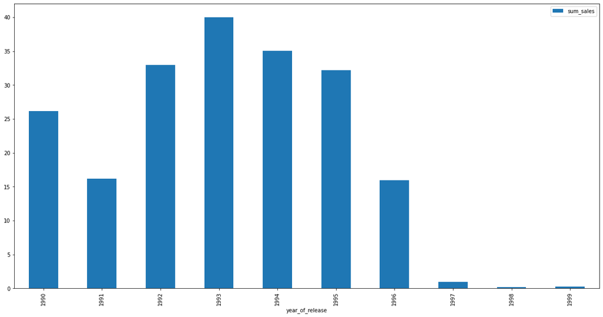

```python
#построим график для платформы SNES, что бы увидеть срок ее действия и как менялись на протяжении всего срока продажи
data[data['platform'] == 'SNES'].pivot_table(index='year_of_release', values='sum_sales', aggfunc='sum').plot(kind='bar', figsize=(20,10))
```

Платформа SNES появилась в 90-х и просуществовала порядка 10 лет. Обьем продаж был незначительным, особенно в сравнении с платформами "современницами". Но и 80-90-е года были началом рассвета компьютерных игр.

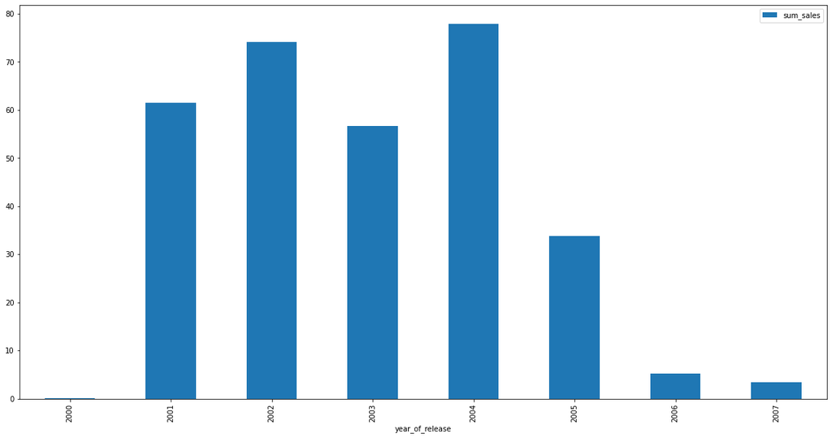

```python
#построим график для платформы GBA, что бы увидеть срок ее действия и как менялись на протяжении всего срока продажи
data[data['platform'] == 'GBA'].pivot_table(index='year_of_release', values='sum_sales', aggfunc='sum').plot(kind='bar', figsize=(20,10))
```

Платформа GBA существовала в начале 2000-х лет, а пик продаж пришелся именно на 2004. В 2007 году платформу сняли с продаж.

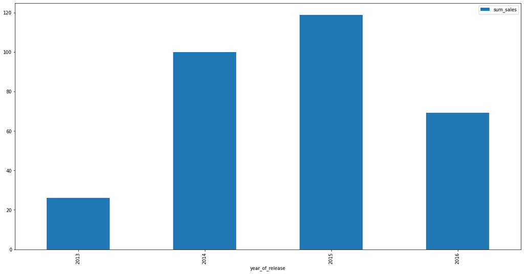

```python
#построим график для платформы PS4, что бы увидеть срок ее действия и как менялись на протяжении всего срока продажи
data[data['platform'] == 'PS4'].pivot_table(index='year_of_release', values='sum_sales', aggfunc='sum').plot(kind='bar', figsize=(20,10))
```

Платформа PS4 существовует и в текущем времени, и пока, за период своего существования, показывает высокий уровень продаж. Возможно ли трактовать, как падение, уровень продаж в 2016 году? Судя по общему объему продаж, год 2016 не является закрытым, т.к. данные представлены не за полный год. Поэтому не станем утверждать, что продажи упали до критического минимума, но и, судя по графику, пик продаж все же пройден.

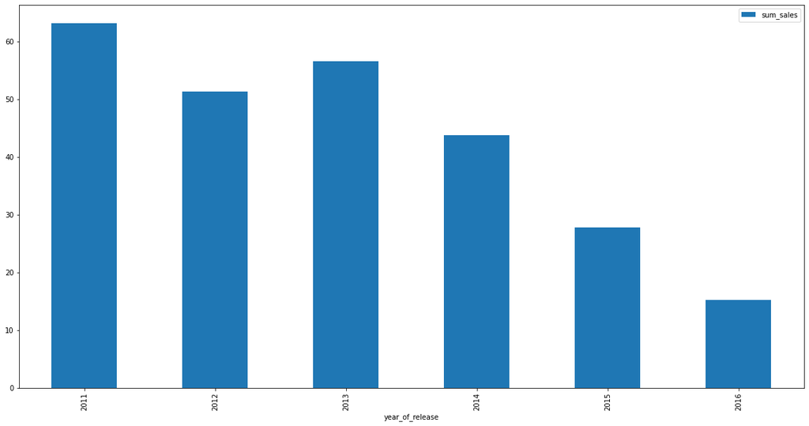

```python
#построим график для платформы 3DS, что бы увидеть срок ее действия и как менялись на протяжении всего срока продажи
data[data['platform'] == '3DS'].pivot_table(index='year_of_release', values='sum_sales', aggfunc='sum').plot(kind='bar', figsize=(20,10))
```

Платформа 3DS так же платформа современник. Ее пик продаж пришелся на 2011 год и в дальнейшем мы видим колебания в большую или меньшую сторону, но без достижения максимума. Наблюдаем равномерный спад и можем предположить, что 2016 или прогнозируемый 2017 год не будет пиковым в данном случае.

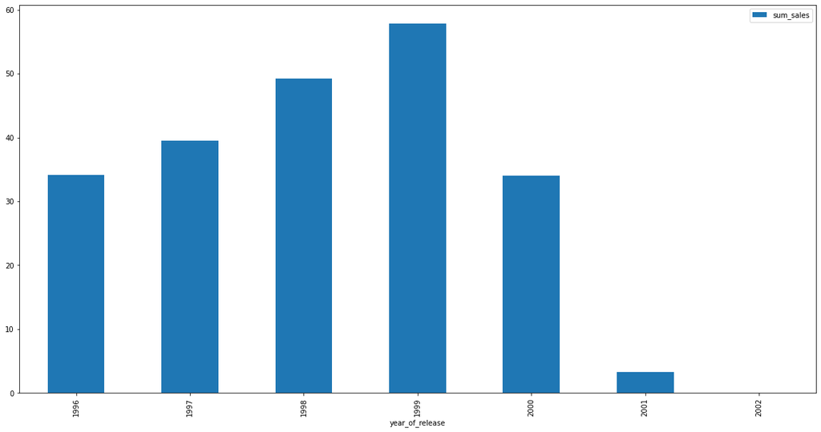

```python
#построим график для платформы N64, что бы увидеть срок ее действия и как менялись на протяжении всего срока продажи
data[data['platform'] == 'N64'].pivot_table(index='year_of_release', values='sum_sales', aggfunc='sum').plot(kind='bar', figsize=(20,10))
```

Платформа N64 просуществовала менее 6 лет. С 1996 года мы видим плавный и уверенный рост продаж до своего пикового значения в 1999 году, а в дальнейшем резкое падение и прекращение продаж платформы в 2002году.

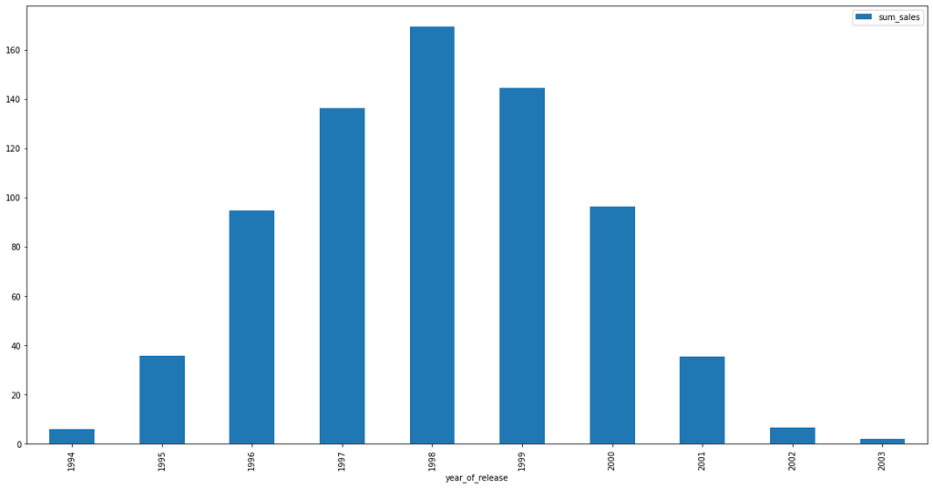

```python
#построим график для платформы PS, что бы увидеть срок ее действия и как менялись на протяжении всего срока продажи
data[data['platform'] == 'PS'].pivot_table(index='year_of_release', values='sum_sales', aggfunc='sum').plot(kind='bar', figsize=(20,10))
```

Платформа PS просуществовала 10 лет. Рост обьема продаж был плавным и уверенным до 1998 года, а в дальнейшем наблюдаем плавное снижение объема продаж, вплоть до окончания продаж платформы в 2003 году. Уровень продаж у платформы был одним из рекордных.

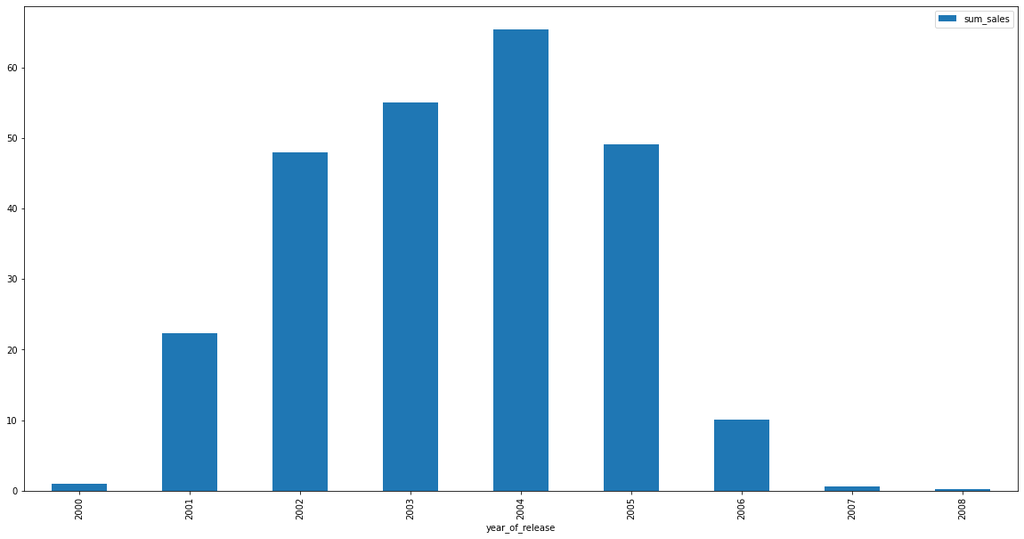

```python
#построим график для платформы XB, что бы увидеть срок ее действия и как менялись на протяжении всего срока продажи
data[data['platform'] == 'XB'].pivot_table(index='year_of_release', values='sum_sales', aggfunc='sum').plot(kind='bar', figsize=(20,10))
```

Платформа XB появилась в начале 2000-х. Пик продаж произошел в 2004 году и далее мы видим резкое падение объема продаж и уход платформы с рынка в 2008 году.

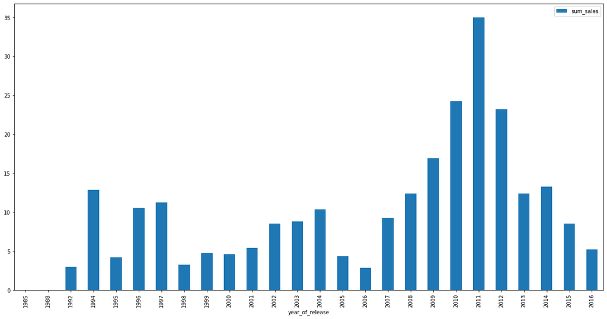

```python
#построим график для платформы PC, что бы увидеть срок ее действия и как менялись на протяжении всего срока продажи
data[data['platform'] == 'PC'].pivot_table(index='year_of_release', values='sum_sales', aggfunc='sum').plot(kind='bar', figsize=(20,10))
```

```
(0.0, 1.0)
```

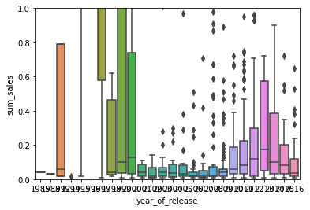

```python
sns.boxplot(data = data[data['platform'] == 'PC'], x='year_of_release', y='sum_sales')
plt.ylim([0, 1])
```

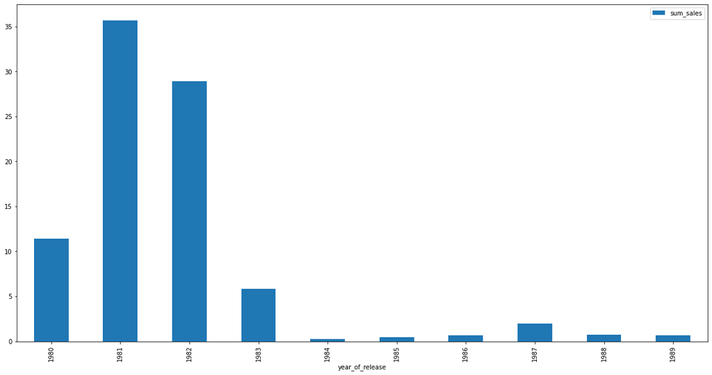

```python
#построим график для платформы 2600, что бы увидеть срок ее действия и как менялись на протяжении всего срока продажи
data[data['platform'] == '2600'].pivot_table(index='year_of_release', values='sum_sales', aggfunc='sum').plot(kind='bar', figsize=(20,10))
```

Платформа 2600 "стояла" у истоков продаж. Основной пик продаж пришелся на 1981 год и уже к началу 90-х платформа прекратила свое существование.

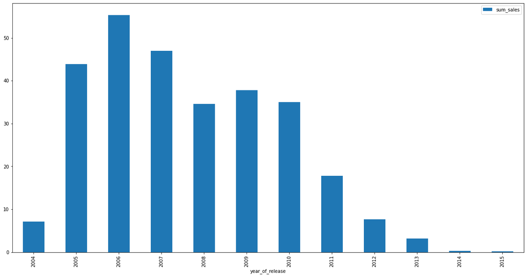

```python
#построим график для платформы PSP, что бы увидеть срок ее действия и как менялись на протяжении всего срока продажи
data[data['platform'] == 'PSP'].pivot_table(index='year_of_release', values='sum_sales', aggfunc='sum').plot(kind='bar', figsize=(20,10))
```

Платформа PSP продержалась на рынке продаж 10 лет. Объм продаж не носил рекордный характер, но был ближе к стабильному до 2010 года. А далее мы видим падение продаж, вплоть до прекращения продаж.

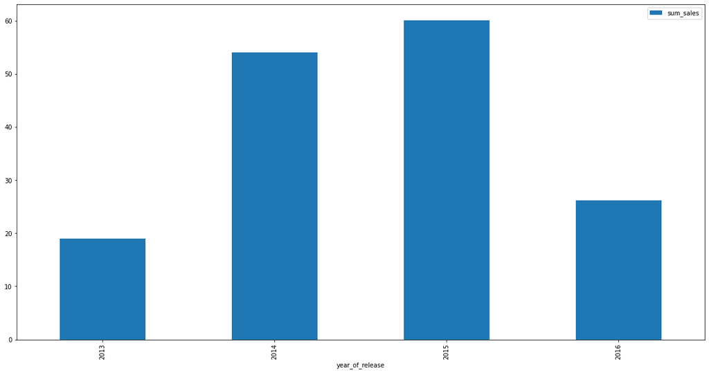

```python
#построим график для платформы XOne, что бы увидеть срок ее действия и как менялись на протяжении всего срока продажи
data[data['platform'] == 'XOne'].pivot_table(index='year_of_release', values='sum_sales', aggfunc='sum').plot(kind='bar', figsize=(20,10))
```

Платформа XOne - одна из новых и современных платформ, открытая после 2010 года. Свое пиковое значение в объеме продаж достигнуто в 2015 году. Даже с учетом, что 2016 год содержит данные о продажах не за все 365 дней, есть сомнения, что он достигнет или превысит этот максимум. Очевидно, что продажи падают, но о закрытии продаж платформы вести речь еще рано.

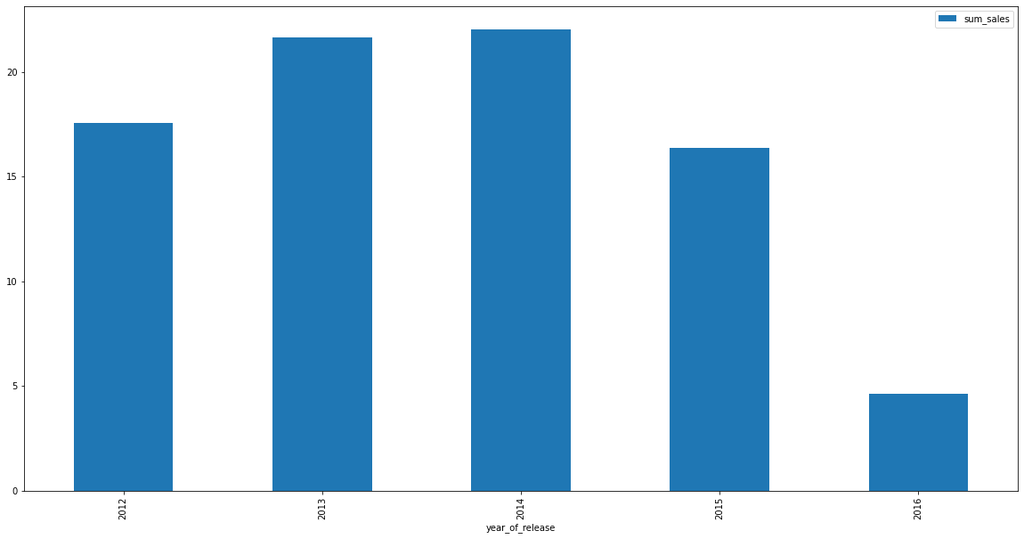

```python
#построим график для платформы WiiU, что бы увидеть срок ее действия и как менялись на протяжении всего срока продажи
data[data['platform'] == 'WiiU'].pivot_table(index='year_of_release', values='sum_sales', aggfunc='sum').plot(kind='bar', figsize=(20,10))
```

Платформа WiiU также платформа современница. Мы видим малозначительный объем продаж за весь период ее существования. Свое пиковое значение в объеме продаж она получила в 2014 году и кроме падения объема мы ничего не наблюдаем, на текущий момент.

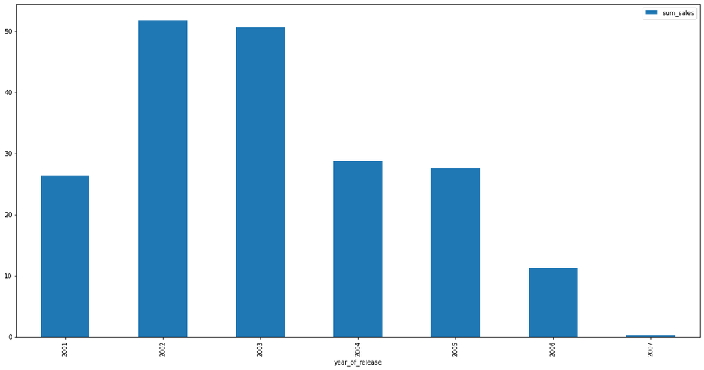

```python
#построим график для платформы GC, что бы увидеть срок ее действия и как менялись на протяжении всего срока продажи
data[data['platform'] == 'GC'].pivot_table(index='year_of_release', values='sum_sales', aggfunc='sum').plot(kind='bar', figsize=(20,10))
```

Платформа GC просуществовала менее 8 лет. Самый высокий объем продаж пришелся на 2002 год. Уже до 2010-х годов платформа не дожила.

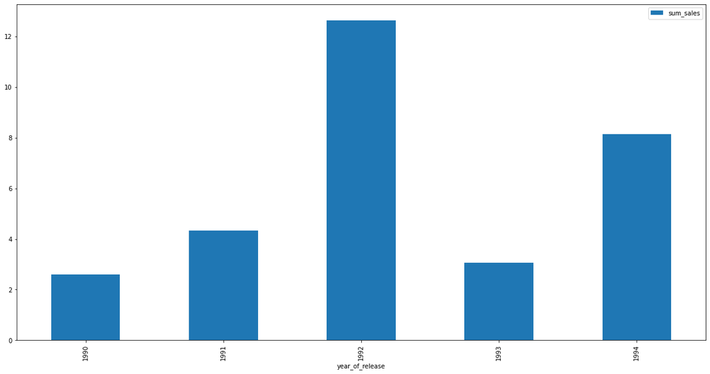

```python
#построим график для платформы GEN, что бы увидеть срок ее действия и как менялись на протяжении всего срока продажи
data[data['platform'] == 'GEN'].pivot_table(index='year_of_release', values='sum_sales', aggfunc='sum').plot(kind='bar', figsize=(20,10))
```

Платформа GEN посуществовала 5 лет. Максимальный объем продаж был достигнут в 1992 году. Судя по последнему году существования платформы, не самый худший был объем продаж перед закрытием платформы. Какие мысли были, которые привели к ее исчезновению, не ясно. Но и рекордов по продажам на общем рынке платформа не воплатила. Предположим, что создатели платформы реалистичны во взглядах и поняли, что максимум уже достигнут и дальнейшие расходы не покроют ни какие доходы, что и привело к прекращению продаж платформы в 1994 году. (или это были "лихие" 90-е и создатель был убит, как потенциальный конкурентноспободный и гениальный в своих игровых идеях, и поэтому резко обрываются продажи)

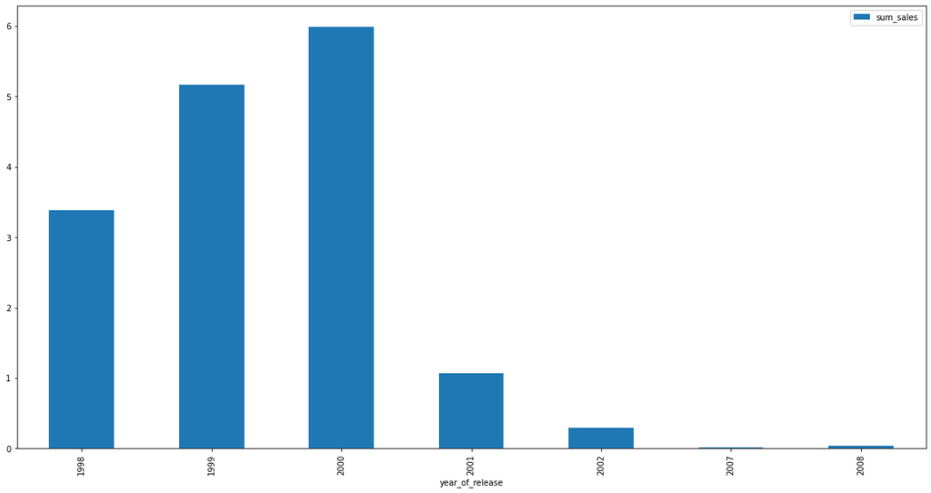

```python
#построим график для платформы DC, что бы увидеть срок ее действия и как менялись на протяжении всего срока продажи
data[data['platform'] == 'DC'].pivot_table(index='year_of_release', values='sum_sales', aggfunc='sum').plot(kind='bar', figsize=(20,10))
```

Платформа DC просуществовала в конце 90-х в начале 2000-х. У данной платформы один из минимальных объемов продаж.

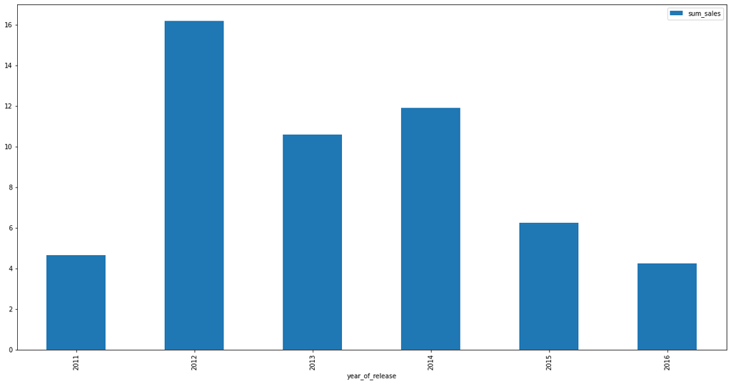

```python
#построим график для платформы PSV, что бы увидеть срок ее действия и как менялись на протяжении всего срока продажи
data[data['platform'] == 'PSV'].pivot_table(index='year_of_release', values='sum_sales', aggfunc='sum').plot(kind='bar', figsize=(20,10))
```

Платформа PSV еще одна платформа современник, которая продолжит работу и в прогнозируемом нами 2017 году. Рост объема продаж и свое пиковое значение, она приобрела в начеле 2010-х годов. Платформа не поставила рекордов по объему продаж в общем рынке, показывает последние года падение и падение.

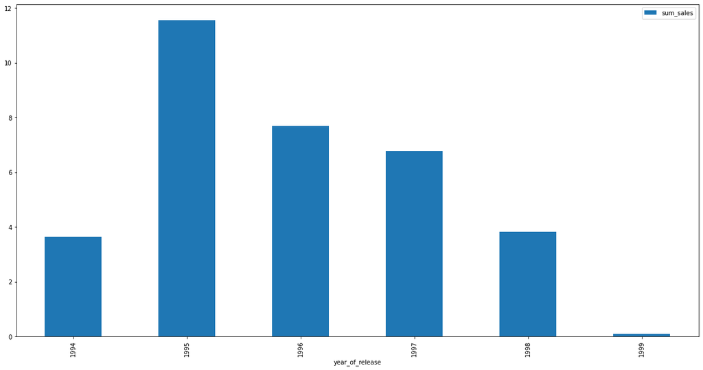

```python
#построим график для платформы SAT, что бы увидеть срок ее действия и как менялись на протяжении всего срока продажи
data[data['platform'] == 'SAT'].pivot_table(index='year_of_release', values='sum_sales', aggfunc='sum').plot(kind='bar', figsize=(20,10))
```

Платформа SAT - одна из непримечательных по объему продаж платформа 90-х. Просуществовала она менее 6 лет. Свой незначительный для общего рынка продаж максимум был достигнут в 1995 году.

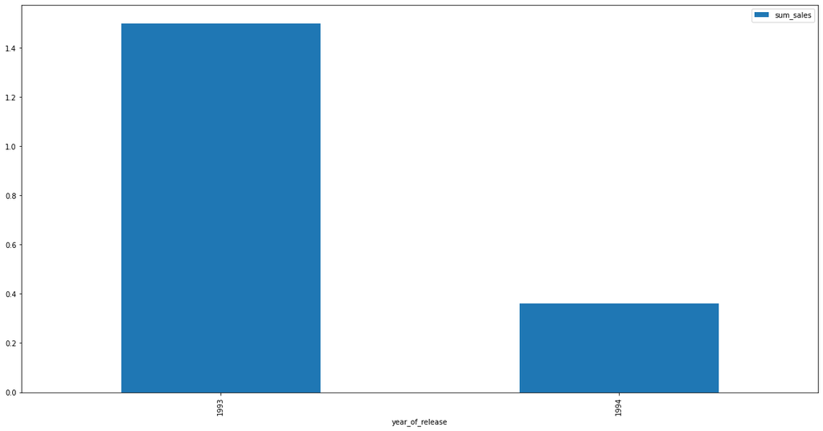

```python
#построим график для платформы SCD, что бы увидеть срок ее действия и как менялись на протяжении всего срока продажи
data[data['platform'] == 'SCD'].pivot_table(index='year_of_release', values='sum_sales', aggfunc='sum').plot(kind='bar', figsize=(20,10))
```

Платформа SCD, очевидно, платформа, созданная под продажу определенной компьютерной игры. Мы видем пик продаж в 1993 году и окончание продаж платформы на следующий год с минимальным объемом.

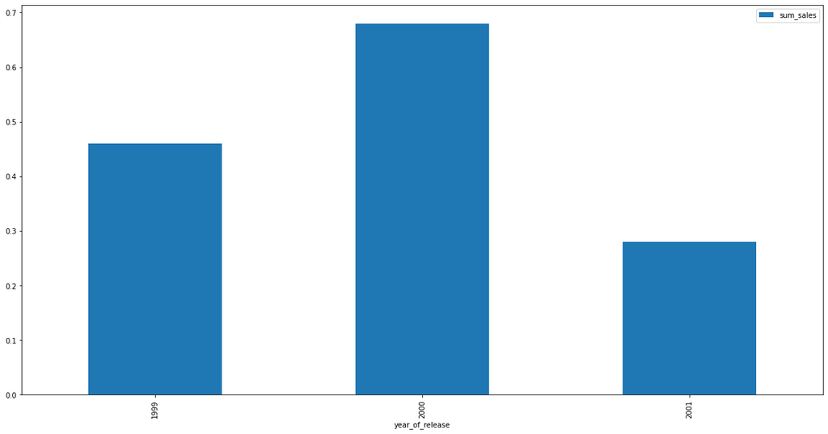

```python
#построим график для платформы WS, что бы увидеть срок ее действия и как менялись на протяжении всего срока продажи
data[data['platform'] == 'WS'].pivot_table(index='year_of_release', values='sum_sales', aggfunc='sum').plot(kind='bar', figsize=(20,10))
```

Платформа WS просуществовала 3 года и свой максимуи достигла в 2000. Общий объем продаж крайне низкий от общего объема рынка.

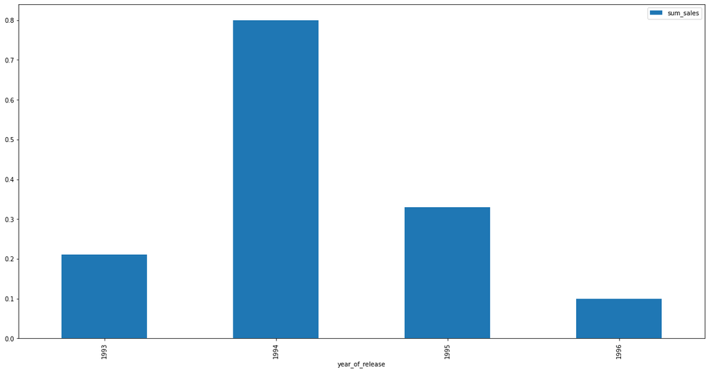

```python
#построим график для платформы NG, что бы увидеть срок ее действия и как менялись на протяжении всего срока продажи

data[data['platform'] == 'NG'].pivot_table(index='year_of_release', values='sum_sales', aggfunc='sum').plot(kind='bar', figsize=(20,10))
```

Платформа NG просуществовала 4 года и свой максимум продаж достигла в 1994 году.

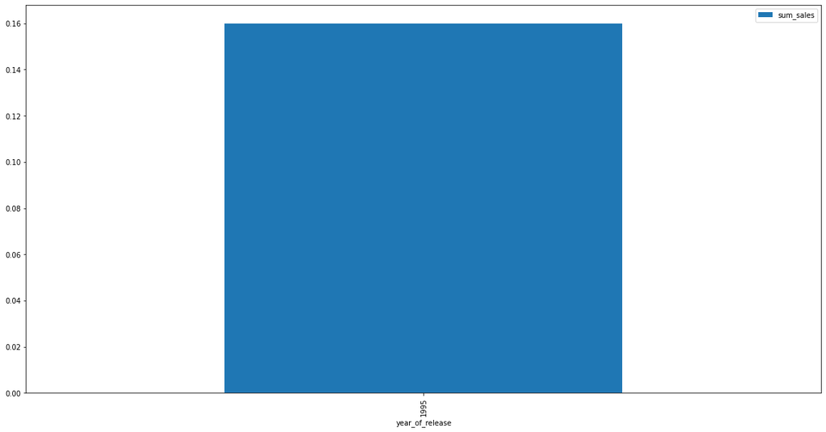

```python
#построим график для платформы TG16, что бы увидеть срок ее действия и как менялись на протяжении всего срока продажи
data[data['platform'] == 'TG16'].pivot_table(index='year_of_release', values='sum_sales', aggfunc='sum').plot(kind='bar', figsize=(20,10))
```

TG16 - платформа под девизом "открыли-продали-закрыли". Рекордный минимум срока работы. Относительный минимум объема продаж (однозначно, достаточный для создателей платформы, иначе и не было бы смысла начинать).

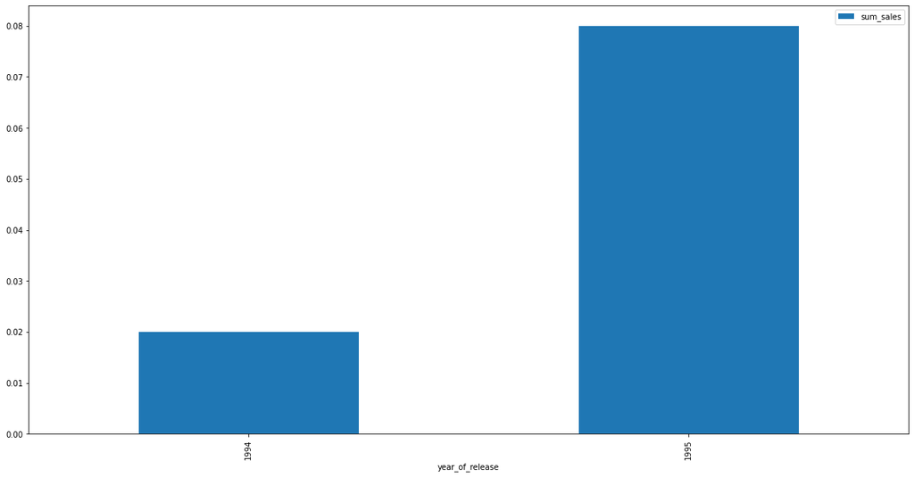

```python
#построим график для платформы 3DO, что бы увидеть срок ее действия и как менялись на протяжении всего срока продажи
data[data['platform'] == '3DO'].pivot_table(index='year_of_release', values='sum_sales', aggfunc='sum').plot(kind='bar', figsize=(20,10))
```

Платформа 3D0 проработала два года в середине 90-х. Так же имела маленький объем от продаж и была оиквидирована с рынка на своем пике объема продаж, что тоже может навести на мысль о криминальном исходе.

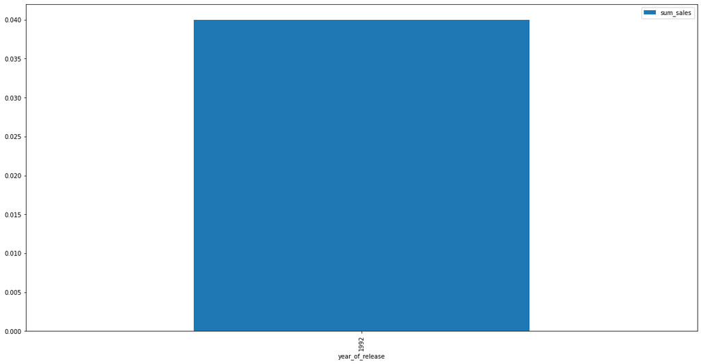

```python
#построим график для платформы GG, что бы увидеть срок ее действия и как менялись на протяжении всего срока продажи
data[data['platform'] == 'GG'].pivot_table(index='year_of_release', values='sum_sales', aggfunc='sum').plot(kind='bar', figsize=(20,10))
```

Платформа GG, существовавшая только в течении 1992 году, так же наводит на мысль о ее открытии именно под продажу оперделенной компьютерной игры. Распродали-закрыли.

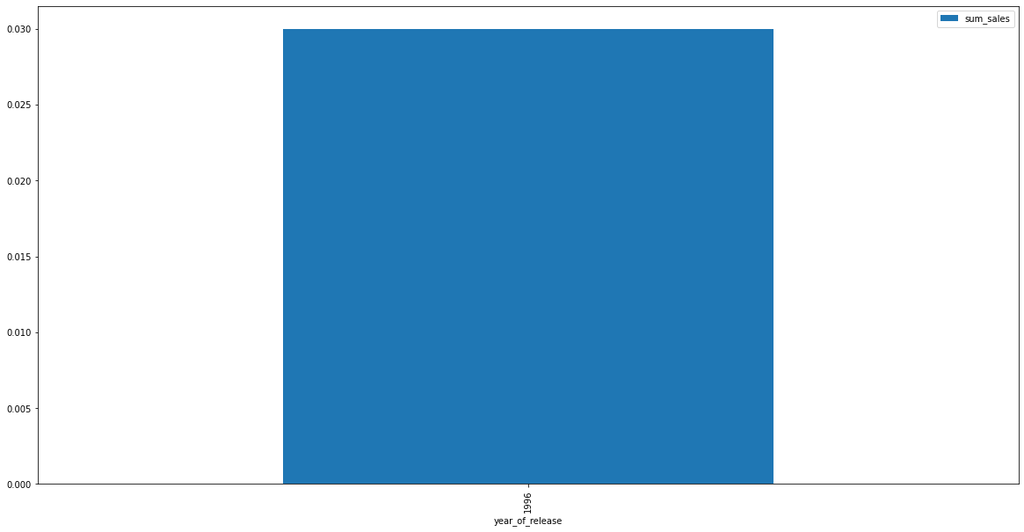

```python
#построим график для платформы PCFX, что бы увидеть срок ее действия и как менялись на протяжении всего срока продажи
data[data['platform'] == 'PCFX'].pivot_table(index='year_of_release', values='sum_sales', aggfunc='sum').plot(kind='bar', figsize=(20,10))
```

Платформа PCFX проработала в 1996 году, не принеся рекордных сумм в объемах продаж.